# pima_dataset

2024-12-16

# PIMA Indians Diabetes dataset

Riferimenti Bibliografici:  
- Smith, J. W., Everhart, J. E., Dickson, W. C., Knowler, W. C. and Johannes, R. S. (1988) Using the ADAP learning algorithm to forecast the onset of diabetes mellitus. In Proceedings of the Symposium on Computer Applications in Medical Care (Washington, 1988), ed. R. A. Greenes, pp. 261–265. Los Alamitos, CA: IEEE Computer Society Press.  
- Newman, D.J. & Hettich, S. & Blake, C.L. & Merz, C.J. (1998). UCI Repository of machine learning databases http://www.ics.uci.edu/~mlearn/MLRepository.html. Irvine, CA: University of California, Department of Information and Computer Science.

Il dataset PIMA Indians studia i predittori associati all’insorgenza di diabete. Il campione include 532 donne della tribù Pima di indiani nativi americani.

- `npreg`: numero di gravidanze
- `glucose`: glucose concentration in an oral glucose tolerance test.
- `pressure`: diastolic blood pressure (mm Hg).
- `skin`: triceps skin fold thickness (mm).
- `bmi`: body bmi index (weight in kg)/(height in m)$^2$.
- `pedigree`: diabetes pedigree function (familiarità).
- `age`: age in years.
- `diabetes`: `pos` o `neg` for diabetic according to WHO criteria.

In particolare siamo interessati alla valutazione dell’effetto di `npreg` sulla presenza di diabete (`diabetes = pos`).

**NOTA BENE:** I dati mancanti sono stati rimossi per comodità di esposizione. La gestione dei dati mancanti (sono casuali? posso sostituorli con valori plausibili senza distorcere i risultati?) è comunque un aspetto cruciale nell’analisi di dati reali e un ambito di ricerca molto attivo.

## Studi osservazionali

Nel caso di studi osservazionali come questo (al contrario degli studi randomizzati) è indispensabile analizzare i dati tenendo in considerazione i possibili **confondenti**; è necessario cioè includerere nel nostro modello tutte le altre variabili che sono possono influenzare la risposta (presenza di diabete).

E’ facile supporre che varibili come `glucose`, `bmi` e `pedigree` siano associate (e predittori) al diabete.

Inoltre variabli fortemente associate al numero di gravidanze `npreg`, come ad esempio l’età `age` (la correlazione tra queste due variabili è 0.642) rischiano di nascondere o ingrandire l’effetto osservato. Ad esempio, se l’età risulta positivamente associata all’insorgenza del diabete, si osserverà anche un’associazione tra numero di gravidanze e diabete. Questa associazione però risulta spuria perchè le donne con maggior numero di gravidanze risulta, in media, anche maggiore d’età.

```r
rm(list=ls())
#### some libraries
#### core functions (to be dropped when the pima package is ready)
library(jointest)
```

```r
library(flipscores)
setwd("G:\\Il mio Drive\\lavorincorso\\PIMA\\talk_catania\\pima-main\\vignette")
source("../R/filippo_utils.R")
source("../R/paolo_utils.R")
source("../R/pima.R")
source("../R/methods.R")
source("../R/spec_curve.R")
source("../R/pima_tree.R")
source("../R/utils_internal.R")
############

# results reporting
library(gtsummary)
library(tidyverse)
library(GGally)
library(knitr)
library(gridExtra)
library(corrplot)
# models
library(MASS)
# read STATA dataset
library(readstata13)
opts_chunk$set(echo=FALSE,
               cache=FALSE,
               prompt=FALSE,
               # tidy=TRUE,
               comment=NA,
               message=FALSE,
               warning=FALSE)

load("pimads.rda")
# nms=names(pimads)
# library(bmi)
# data("Pima.tr")
# names(Pima.tr)=nms[-5]
# pimads=Pima.tr
pimads$insulin=NULL

data("Pima.tr")
names(pimads)[-c(2,3,6,8)]=names(Pima.tr)[-c(2,3,6,8)]
names(pimads)
```

```
## [1] "npreg"    "glucose"  "pressure" "skin"     "bmi"      "pedigree" "age"
## [8] "diabetes"
```

```r
table(pimads$type)
```

```
## < table of extent 0 >
```

```r
pimads=na.omit(pimads)
writexl::write_xlsx(pimads,path="PIMAds.xlsx")
```

## Analisi Esplorativa e Descrittiva

```
     npreg           glucose          pressure           skin
 Min.   : 0.000   Min.   : 56.00   Min.   : 24.00   Min.   : 7.00
 1st Qu.: 1.000   1st Qu.: 98.75   1st Qu.: 64.00   1st Qu.:22.00
 Median : 2.000   Median :115.00   Median : 72.00   Median :29.00
 Mean   : 3.517   Mean   :121.03   Mean   : 71.51   Mean   :29.18
 3rd Qu.: 5.000   3rd Qu.:141.25   3rd Qu.: 80.00   3rd Qu.:36.00
 Max.   :17.000   Max.   :199.00   Max.   :110.00   Max.   :99.00
      bmi           pedigree           age        diabetes
 Min.   :18.20   Min.   :0.0850   Min.   :21.00   neg:355
 1st Qu.:27.88   1st Qu.:0.2587   1st Qu.:23.00   pos:177
 Median :32.80   Median :0.4160   Median :28.00
 Mean   :32.89   Mean   :0.5030   Mean   :31.61
 3rd Qu.:36.90   3rd Qu.:0.6585   3rd Qu.:38.00
 Max.   :67.10   Max.   :2.4200   Max.   :81.00
```

```r
pimads %>% tbl_summary(by = diabetes) %>% add_p() %>%as_gt() %>%   gt::as_raw_html()
```

| **Characteristic** | **neg** N = 355<sup>1</sup> | **pos** N = 177<sup>1</sup> | **p-value**<sup>2</sup> |
| --- | --- | --- | --- |
| npreg | 2.0 (1.0, 4.0) | 4.0 (1.0, 8.0) | <0.001 |
| glucose | 106 (93, 124) | 144 (118, 171) | <0.001 |
| pressure | 70 (62, 78) | 74 (68, 84) | <0.001 |
| skin | 27 (19, 33) | 32 (27, 39) | <0.001 |
| bmi | 31 (26, 36) | 35 (32, 39) | <0.001 |
| pedigree | 0.37 (0.24, 0.59) | 0.54 (0.33, 0.79) | <0.001 |
| age | 25 (22, 33) | 35 (27, 44) | <0.001 |

<sup>1</sup> Median (Q1, Q3)  
<sup>2</sup> Wilcoxon rank sum test

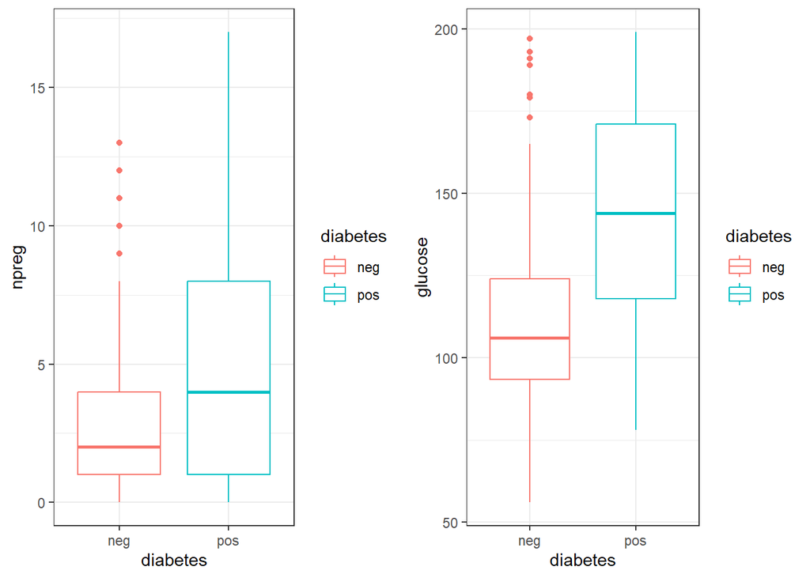

```r
#
#
 p1<-ggplot(pimads, aes(x=diabetes, y=npreg, color=diabetes)) +
   geom_boxplot()+theme_bw()
 p2<-ggplot(pimads, aes(x=diabetes, y=glucose, color=diabetes)) +
   geom_boxplot()+theme_bw()

 grid.arrange(p1,p2,ncol=2)
```

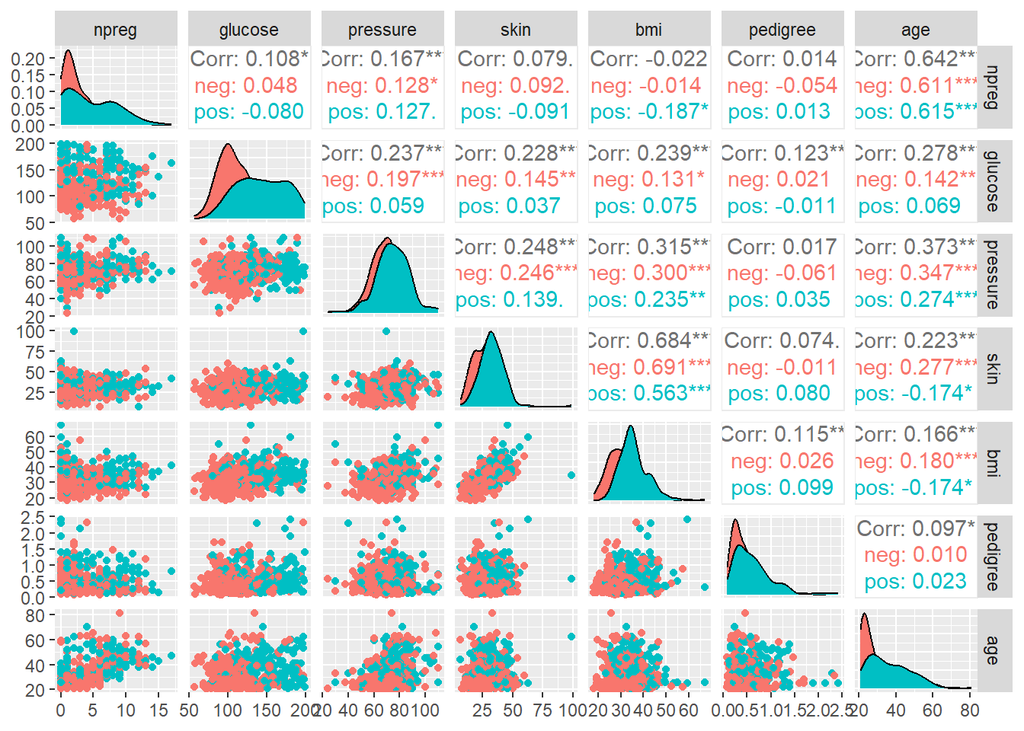

```r
pm <- ggpairs(pimads, columns = c(1:7),aes(color= diabetes),upper = list(continuous = wrap("cor", method = "spearman")))
pm
```

Correlazione molto alta tra `pelle` e `bmi` (0,68) e tra `età` e `npreg` (0,64),

## Modello Logistico

Disegno di studio osservazionale:

- Esito: Diabete
- Determinante: numero di gravidanze
- Confondenti: glucosio, pressione, pelle, bmi, pedigree, età.

Consideriamo la regressione logistica

$$logit(\pi)=log(\pi/(1-\pi))=\beta_0+\beta_1\mbox{npreg}+\beta_2\mbox{glucose}+\beta_3\mbox{pressure}+\beta_4\mbox{skin}+\beta_5\mbox{bmi}+\beta_6\mbox{pedigree}+\beta_7\mbox{age}$$
dove $\pi$ è la probabilità di diabete e quindi (sostituiamo $\beta_0+\beta_1\mbox{npreg}+\beta_2\mbox{glucose}+\beta_3\mbox{pressure}+\beta_4\mbox{skin}+\beta_5\mbox{bmi}+\beta_6\mbox{pedigree}+\beta_7\mbox{age} = XB$):

$$\mbox{diabetes} \sim
Bernulli(\pi=expit(XB))$$
$expit()$ è l’inversa della funzione logit:
$$expit(XB)=\frac{e^{XB}}{1+e^{XB}}$$

## MULTIVERSE ANALYSIS

Nell’analisi di dati reali non sappiamo se (e non è sempre verosimile assumere che) il legame dei preidittori sia lineare, potrebbe essere opportuno considerare effetti non lineari delle variabili, come ad esempio la trasformazione quadratica ($X^2$) o la radice quadrata $\sqrt{X}$. Questo può valere per tutti i predittori.

Nei dati reali inoltre potremmo cercare se si sono osservazioni troppo influenti (leverage) o outlier. Potremmo anche valutare diversi modi di imputare i dati mancanti. O di includere interazioni tra variabili etc…

Proviamo qualche modello possibile

```
Call:
glm(formula = diabetes ~ ., family = binomial, data = pimads)

Coefficients:
             Estimate Std. Error z value Pr(>|z|)
(Intercept) -9.554651   0.994217  -9.610  < 2e-16 ***
npreg        0.122517   0.043743   2.801 0.005097 **
glucose      0.035321   0.004244   8.322  < 2e-16 ***
pressure    -0.007695   0.010314  -0.746 0.455602
skin         0.006774   0.014759   0.459 0.646242
bmi          0.082678   0.023334   3.543 0.000395 ***
pedigree     1.308708   0.364040   3.595 0.000324 ***
age          0.026375   0.014000   1.884 0.059581 .
---
Signif. codes:  0 '***' 0.001 '**' 0.01 '*' 0.05 '.' 0.1 ' ' 1

(Dispersion parameter for binomial family taken to be 1)

    Null deviance: 676.79  on 531  degrees of freedom
Residual deviance: 466.32  on 524  degrees of freedom
AIC: 482.32

Number of Fisher Scoring iterations: 5
```

```
Call:
glm(formula = diabetes ~ . - age + sqrt(age), family = binomial,
    data = pimads)

Coefficients:
              Estimate Std. Error z value Pr(>|z|)
(Intercept) -10.773675   1.198241  -8.991  < 2e-16 ***
npreg         0.108802   0.044573   2.441 0.014647 *
glucose       0.035115   0.004246   8.270  < 2e-16 ***
pressure     -0.008995   0.010338  -0.870 0.384237
skin          0.006263   0.014816   0.423 0.672502
bmi           0.083496   0.023337   3.578 0.000347 ***
pedigree      1.294344   0.364344   3.553 0.000382 ***
sqrt(age)     0.397604   0.175404   2.267 0.023403 *
---
Signif. codes:  0 '***' 0.001 '**' 0.01 '*' 0.05 '.' 0.1 ' ' 1

(Dispersion parameter for binomial family taken to be 1)

    Null deviance: 676.79  on 531  degrees of freedom
Residual deviance: 464.71  on 524  degrees of freedom
AIC: 480.71

Number of Fisher Scoring iterations: 5
```

```
Call:
glm(formula = diabetes ~ . - age + sqrt(age) - npreg + I(npreg^2),
    family = binomial, data = pimads)

Coefficients:
              Estimate Std. Error z value Pr(>|z|)
(Intercept) -10.640101   1.209553  -8.797  < 2e-16 ***
glucose       0.035166   0.004257   8.261  < 2e-16 ***
pressure     -0.009560   0.010338  -0.925 0.355053
skin          0.006217   0.014850   0.419 0.675485
bmi           0.080733   0.023284   3.467 0.000526 ***
pedigree      1.293180   0.365009   3.543 0.000396 ***
sqrt(age)     0.427970   0.166805   2.566 0.010297 *
I(npreg^2)    0.009252   0.003734   2.478 0.013213 *
---
Signif. codes:  0 '***' 0.001 '**' 0.01 '*' 0.05 '.' 0.1 ' ' 1

(Dispersion parameter for binomial family taken to be 1)

    Null deviance: 676.79  on 531  degrees of freedom
Residual deviance: 464.25  on 524  degrees of freedom
AIC: 480.25

Number of Fisher Scoring iterations: 5
```

Tutti i confondenti sono continui. Decidiamo di esplorare per ogni predittore le seguenti trasformazioni:  
- Radice quadrata ($sqrt(x)$);  
- identità ($x$);  
- Polinomio di secondo ordine ($x+x^2$) (o semplicemente $x^2$ per npreg).

```r
########################################### possible specifications:
combinations_matrix=expand.grid(list(
  c("npreg","sqrt(npreg)","I(npreg^2)"),
  c("age","sqrt(age)","poly(age, 2)"),
  c("glucose","sqrt(glucose)","poly(glucose, 2)"),
  c("pedigree","sqrt(pedigree)","poly(pedigree, 2)"),
  c("bmi","sqrt(bmi)","poly(bmi, 2)")))

combinations=apply(combinations_matrix,1,paste,collapse="+")
```

Poi stimiamo tutti i modelli ($3^5=243$) specificati

```r
##################### one list of formulas for each model:
#######
formulas1=sapply(combinations,function(cmb) paste0("diabetes ~ ",cmb," + pressure + skin"))
mod1=glm(as.formula(formulas1[1]),data=pimads,family=binomial)
summary(mod1)
```

```
Call:
glm(formula = as.formula(formulas1[1]), family = binomial, data = pimads)

Coefficients:
             Estimate Std. Error z value Pr(>|z|)
(Intercept) -9.554651   0.994217  -9.610  < 2e-16 ***
npreg        0.122517   0.043743   2.801 0.005097 **
age          0.026375   0.014000   1.884 0.059581 .
glucose      0.035321   0.004244   8.322  < 2e-16 ***
pedigree     1.308708   0.364040   3.595 0.000324 ***
bmi          0.082678   0.023334   3.543 0.000395 ***
pressure    -0.007695   0.010314  -0.746 0.455602
skin         0.006774   0.014759   0.459 0.646242
---
Signif. codes:  0 '***' 0.001 '**' 0.01 '*' 0.05 '.' 0.1 ' ' 1

(Dispersion parameter for binomial family taken to be 1)

    Null deviance: 676.79  on 531  degrees of freedom
Residual deviance: 466.32  on 524  degrees of freedom
AIC: 482.32

Number of Fisher Scoring iterations: 5
```

```r
#stimiamo tutti i modelli:
mods=lapply(formulas1, function(frml) update(mod1,formula. = as.formula(frml)))
```

Utilizzando la funzione applichiamo la procedura PIMA all’elenco di modelli all’interno dell’elenco mods. E correggiamo per molteplicità (min-p).

```r
library(pima)

# res=pima(mods,tested_coeffs =  c("npreg","sqrt(npreg)","I(npreg^2)"),n_flips = 2000,
#                           score_type = "standardized",seed = 1)

# res=p.adjust(res,"minp",alphas=c(0.001, (1:99)/1000, (1:9)/10))
# save(res, file="G:/Il mio Drive/lavorincorso/PIMA/talk_catania/pima_res.Rdata")
 load("G:/Il mio Drive/lavorincorso/PIMA/talk_catania/pima_res.Rdata")

summary(res)
```

```
                                                                       Model
1                                             npreg+age+glucose+pedigree+bmi
2                                       sqrt(npreg)+age+glucose+pedigree+bmi
3                                        I(npreg^2)+age+glucose+pedigree+bmi
4                                       npreg+sqrt(age)+glucose+pedigree+bmi
5                                 sqrt(npreg)+sqrt(age)+glucose+pedigree+bmi
6                                  I(npreg^2)+sqrt(age)+glucose+pedigree+bmi
7                                    npreg+poly(age, 2)+glucose+pedigree+bmi
8                              sqrt(npreg)+poly(age, 2)+glucose+pedigree+bmi
9                               I(npreg^2)+poly(age, 2)+glucose+pedigree+bmi
10                                      npreg+age+sqrt(glucose)+pedigree+bmi
11                                sqrt(npreg)+age+sqrt(glucose)+pedigree+bmi
12                                 I(npreg^2)+age+sqrt(glucose)+pedigree+bmi
13                                npreg+sqrt(age)+sqrt(glucose)+pedigree+bmi
14                          sqrt(npreg)+sqrt(age)+sqrt(glucose)+pedigree+bmi
```

[output cut: 717 more lines]

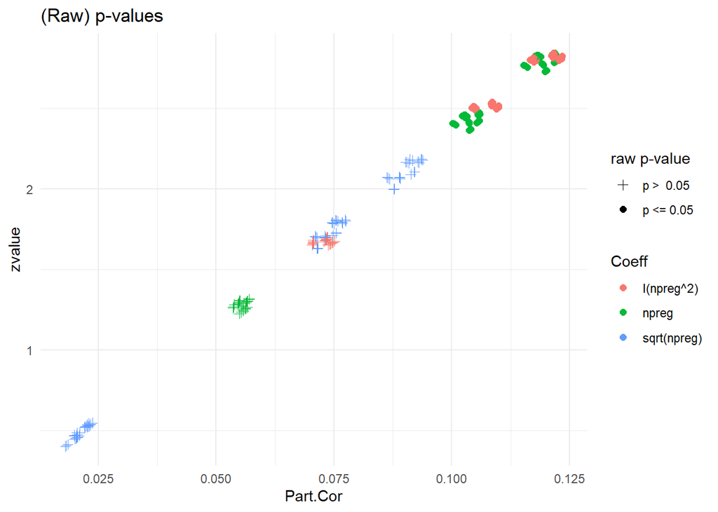

```r
source("G:/Il mio Drive/lavorincorso/PIMA/talk_catania/funzioni_new.R")
plot.pima(res,p.values="raw")
```

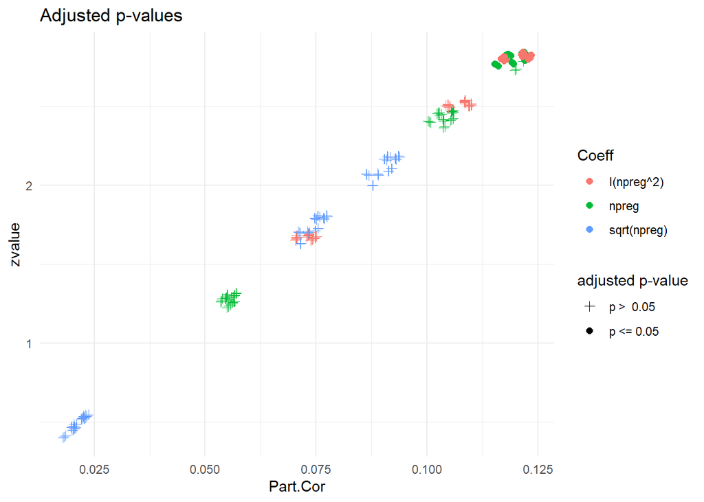

```r
plot.pima(res,p.values="adjusted")
```

```r
# pseudo |Z| = qnorm ( 1 - p/2) (quantile di una normale standard)
```

L’output è composto da:  
- `Tspace`: tabella delle statistiche test (osservate nella prima riga)  
- `summary_table`: summary dei risultati  
- `mods`: list dei 243 modelli stimati (uno per ogni specifica)  
- `info`: informazioni sulle specifiche (oggetto ausiliario)

## Scegli il tuo modello

Ora possiamo considerare i modelli i cui p-value sono ancora significativi dopo la correzione.

Possiamo prendere quello con significatività più elevata (minimo p-value) o quello che ci sembra ragionevole:

```r
sel_model<-which(res$summary_table$p.adj<0.05)
sel_model
```

```
 [1]   1   3  10  12  19  21  28  30  37  39  46  48  57  66  75  82  84  91  93
[20] 100 102 109 111 118 120 127 129 136 138 147 154 156 163 165 172 174 181 183
[39] 190 192 199 201 208 210 219 228 237
```

```r
tab=res$summary_table
tab$.assign=NULL
tab[sel_model,]
```

```
                                                             Model      Coeff
1                                   npreg+age+glucose+pedigree+bmi      npreg
3                              I(npreg^2)+age+glucose+pedigree+bmi I(npreg^2)
10                            npreg+age+sqrt(glucose)+pedigree+bmi      npreg
12                       I(npreg^2)+age+sqrt(glucose)+pedigree+bmi I(npreg^2)
19                         npreg+age+poly(glucose, 2)+pedigree+bmi      npreg
21                    I(npreg^2)+age+poly(glucose, 2)+pedigree+bmi I(npreg^2)
28                            npreg+age+glucose+sqrt(pedigree)+bmi      npreg
30                       I(npreg^2)+age+glucose+sqrt(pedigree)+bmi I(npreg^2)
37                      npreg+age+sqrt(glucose)+sqrt(pedigree)+bmi      npreg
39                 I(npreg^2)+age+sqrt(glucose)+sqrt(pedigree)+bmi I(npreg^2)
46                   npreg+age+poly(glucose, 2)+sqrt(pedigree)+bmi      npreg
48              I(npreg^2)+age+poly(glucose, 2)+sqrt(pedigree)+bmi I(npreg^2)
57                    I(npreg^2)+age+glucose+poly(pedigree, 2)+bmi I(npreg^2)
66              I(npreg^2)+age+sqrt(glucose)+poly(pedigree, 2)+bmi I(npreg^2)
```

[output cut: 81 more lines]

## Esplorazione dei risultati

Quali caratteristiche hanno i modelli significativi?

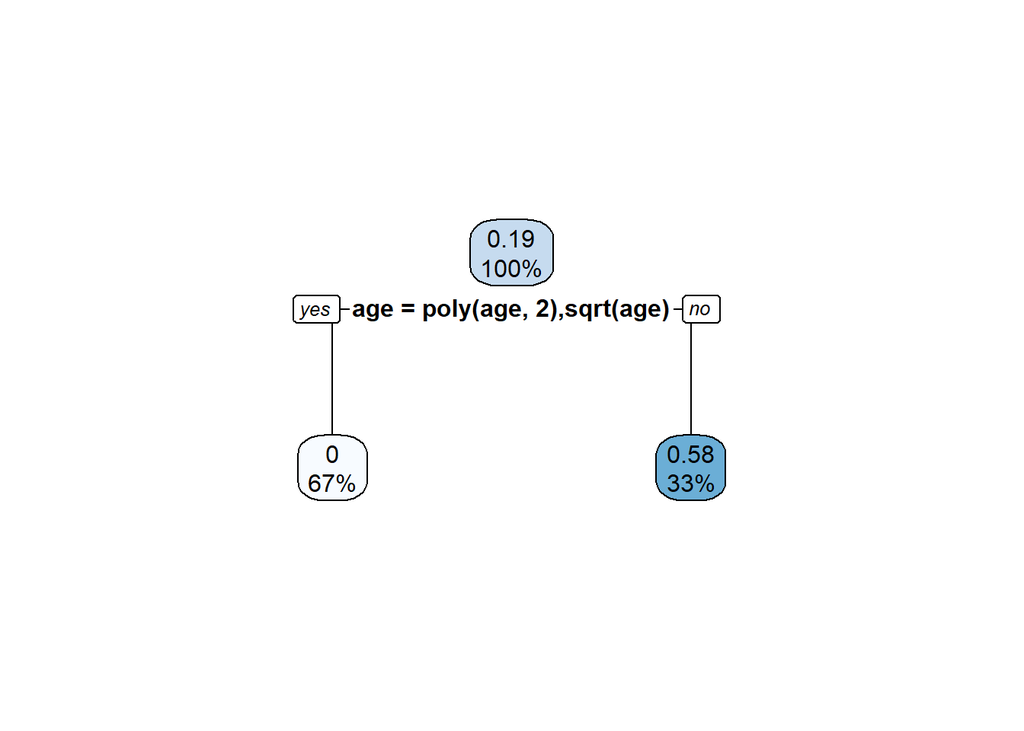

[output not shown]

## Aspetti problematici

Naturalmente tutte queste conclusioni valgono fin tanto che sono valide le assunzioni che facciamo sui modelli che stimiamo. E’ opportuno fare delle valutazioni di adeguatezza dei modelli stimati (es grafici di diagnostica, indici di fit).